# Getting things into the right order

Claus O. Wilke

## Introduction

In this worksheet, we will discuss how to manipulate factor levels such that plots show visual elements in the correct order.

We will be using four R packages, **tidyverse** for various data manipulation functions and **palmerpenguins**, **gapminder**, and **ggridges** for the `penguins`, `gapminder`, and `Aus_athletes` datasets, respectively.

```r
# load required libraries
library(tidyverse)
library(palmerpenguins)
library(gapminder)
library(ggridges)
```

We will be working with the dataset `penguins`, which contains data on individual penguins on Antarctica.

```r
penguins
```

```
# A tibble: 344 × 8
   species island    bill_length_mm bill_depth_mm flipper_length_mm body_mass_g
   <fct>   <fct>              <dbl>         <dbl>             <int>       <int>
 1 Adelie  Torgersen           39.1          18.7               181        3750
 2 Adelie  Torgersen           39.5          17.4               186        3800
 3 Adelie  Torgersen           40.3          18                 195        3250
 4 Adelie  Torgersen           NA            NA                  NA          NA
 5 Adelie  Torgersen           36.7          19.3               193        3450
 6 Adelie  Torgersen           39.3          20.6               190        3650
 7 Adelie  Torgersen           38.9          17.8               181        3625
 8 Adelie  Torgersen           39.2          19.6               195        4675
 9 Adelie  Torgersen           34.1          18.1               193        3475
10 Adelie  Torgersen           42            20.2               190        4250
# … with 334 more rows, and 2 more variables: sex <fct>, year <int>
```

We will also be working with the dataset `gapminder`, which contains information about life expectancy, population number, and GDP for 142 different countries.

```r
gapminder
```

```
# A tibble: 1,704 × 6
   country     continent  year lifeExp      pop gdpPercap
   <fct>       <fct>     <int>   <dbl>    <int>     <dbl>
 1 Afghanistan Asia       1952    28.8  8425333      779.
 2 Afghanistan Asia       1957    30.3  9240934      821.
 3 Afghanistan Asia       1962    32.0 10267083      853.
 4 Afghanistan Asia       1967    34.0 11537966      836.
 5 Afghanistan Asia       1972    36.1 13079460      740.
 6 Afghanistan Asia       1977    38.4 14880372      786.
 7 Afghanistan Asia       1982    39.9 12881816      978.
 8 Afghanistan Asia       1987    40.8 13867957      852.
 9 Afghanistan Asia       1992    41.7 16317921      649.
10 Afghanistan Asia       1997    41.8 22227415      635.
# … with 1,694 more rows
```

Finally, we will be working with the dataset `Aus_athletes`, which contains various physiological measurements made on athletes competing in different sports.

```r
head(Aus_athletes)
```

```
   rcc wcc   hc   hg ferr   bmi   ssf pcBfat   lbm height weight sex      sport
1 3.96 7.5 37.5 12.3   60 20.56 109.1  19.75 63.32  195.9   78.9   f basketball
2 4.41 8.3 38.2 12.7   68 20.67 102.8  21.30 58.55  189.7   74.4   f basketball
3 4.14 5.0 36.4 11.6   21 21.86 104.6  19.88 55.36  177.8   69.1   f basketball
4 4.11 5.3 37.3 12.6   69 21.88 126.4  23.66 57.18  185.0   74.9   f basketball
5 4.45 6.8 41.5 14.0   29 18.96  80.3  17.64 53.20  184.6   64.6   f basketball
6 4.10 4.4 37.4 12.5   42 21.04  75.2  15.58 53.77  174.0   63.7   f basketball
```

## Manual reordering

The simplest form of reordering is manual, where we state explicitly in which order we want some graphical element to appear. We reorder manually with the function `fct_relevel()`, which takes as arguments the variable to reorder and the levels we want to reorder, in the order in which we want them to appear.

Here is a simple example. We create a factor `x` with levels `"A"`, `"B"`, `"C"`, in that order, and then we reorder the levels to `"B"`, `"C"`, `"A"`.

```r
x <- factor(c("A", "B", "A", "C", "B"))
x
```

```
[1] A B A C B
Levels: A B C
```

```r
fct_relevel(x, "B", "C", "A")
```

```
[1] A B A C B
Levels: B C A
```

Try this out for yourself. Place the levels into a few different orderings. Also try listing only some of the levels to reorder.

```r
x <- factor(c("A", "B", "A", "C", "B"))
x

fct_relevel(x, ___)
```

Now we apply this concept to a ggplot graph. We will work with the following boxplot visualization of the distribution of bill length versus penguin species.

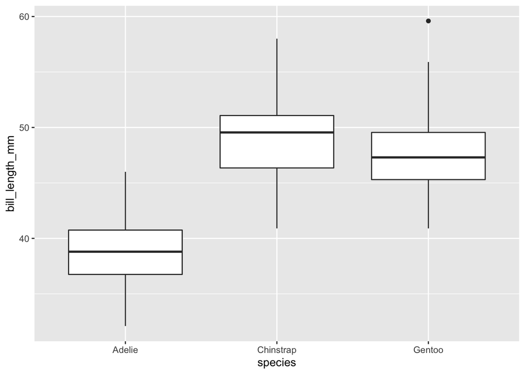

```r
penguins %>%
  ggplot(aes(species, bill_length_mm)) +
  geom_boxplot()
```

Use the function `fct_relevel()` to place the three species into the order Chinstrap, Gentoo, Adelie. (*Hint:* You will have to use a `mutate()` statement to modify the `species` column.)

Now flip the x and y axes, making sure that the order remains Chinstrap, Gentoo, Adelie from top to bottom.

## Reordering based on frequency

Manual reordering is cumbersome if there are many levels that need to be reorderd. Therefore, we often use functions that can reorder automatically based on some quantitative criterion. For example, we can use `fct_infreq()` to order a factor based on the number of occurrences of each level in the dataset. And we can reverse the order of a factor using the function `fct_rev()`. These two functions are particularly useful for making bar plots.

Consider the following plot of the number of athletes competing in various sports in the `Aus_athletes` dataset. This plot is problematic because the sports are arranged in an arbitrary (here: alphabetic) order that is not meaningful for the data shown.

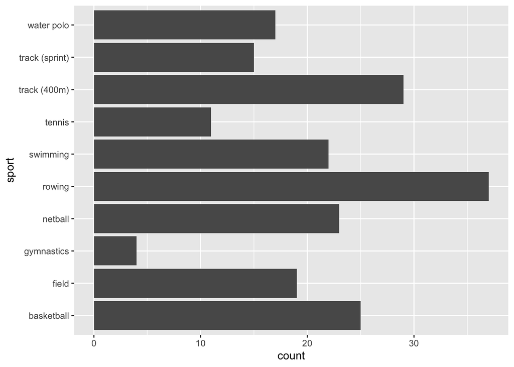

```r
Aus_athletes %>%
  ggplot(aes(y = sport)) +
  geom_bar()
```

Reorder the `sport` column so that the sport with the most athletes appears on top and the sport with the least athletes at the bottom.

## Reordering based on numerical values

Another common problem we encounter is that we want to order a factor based on some other numerical variable, possibly after we have calculated some summary statistic such as the median, minimum, or maximum.

As an example for this problem, we consider a plot of the life expectancy in various countries in the Americas over time, shown as colored tiles.

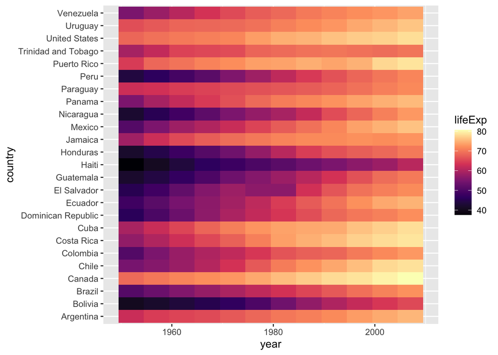

```r
gapminder %>%
  filter(continent == "Americas") %>%
  ggplot(aes(year, country, fill = lifeExp)) +
  geom_tile() +
  scale_fill_viridis_c(option = "A")
```

The default alphabetic ordering creates a meaningless color pattern that is difficult to read. It would make more sense to order the countries by some function of the life expectancy values, such as the minimum, median, or maximum value. We can do this with the function `fct_reorder()`, which takes three arguments: The factor to reorder, the numerical variable on which to base the ordering, and the name of a function (such as `min`, `median`, `max`) to be applied to calculate the ordering statistic.

Modify the above plot so the countries are ordered by their median life expectancy over the observed time period.

Try other orderings, such as `min`, `max`, or `mean`.

Next, instead of plotting this data as colored tiles, plot it as lines, using facets to make separate panels for each country.

Again, try various orderings, including `min`, `max`, or `mean`.

## Lumping of factor levels

Finally, we sometimes have factors with too many levels and we want to combine some into a catch-all level such as “Other”. We illustrate this concept with the following plot, which shows BMI (body-mass index) versus height for male athletes, broken down by sport.

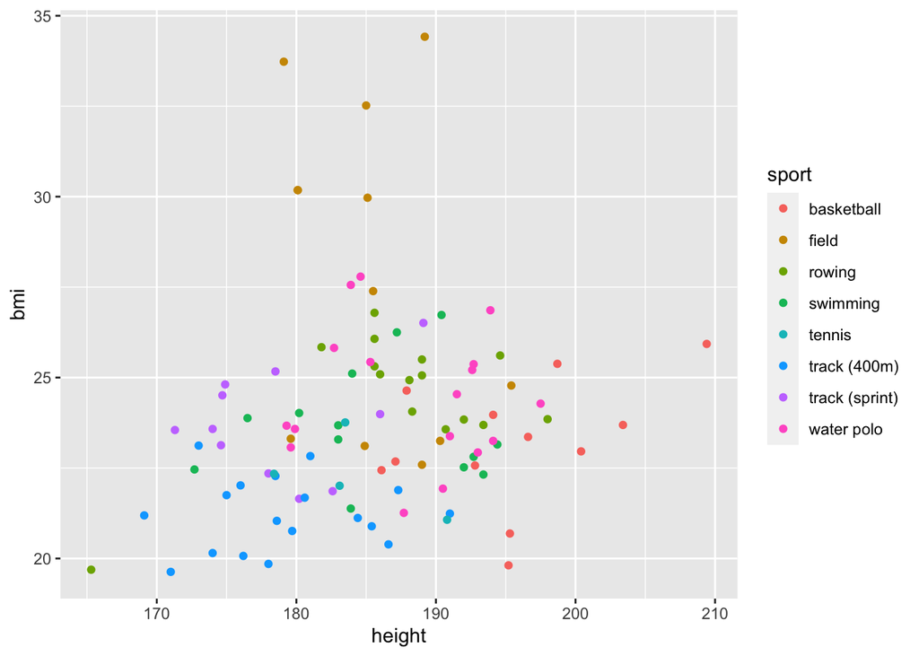

```r
Aus_athletes %>%
  filter(sex == "m") %>%
  ggplot(aes(height, bmi, color = sport)) +
  geom_point()
```

We want to modify this plot so that all sports other than basketball and water polo are shown as “Other”. To achieve this goal, you will have to create a new column called `sport_lump` that contains a lumped version of the `sport` factor.

The function that does the lumping is called `fct_other()`, and it takes as argument the variable to lump and an argument `keep` listing the values to keep or alternatively an argument `drop` listing the values to drop. Since you want to keep only basketball and water polo, use the variant with the `keep` argument.

```r
Aus_athletes %>%
  filter(sex == "m") %>%
  mutate(
    sport_lump = ___
  ) %>%
  ggplot(aes(height, bmi, color = sport_lump)) +
  geom_point()
```

Now use the variant of the `fct_other()` function with the `drop` argument. Drop field, rowing, and tennis from the sports considered individually.

Finally, try other lumping functions also. For example, the function `fct_lump_n()` retains the *n* most frequent levels and lump all others into `"Other"`. See if you can create a meaningful example with the `Aus_athletes` dataset that uses the `fct_lump_n()` function. *Hint:* Try to make a bar plot, similar to the one we made in the section on reordering based on frequency.